# Housing Price Prediction using Advanced Regression

**The Business Problem: The dataset of the project is of residential homes in Ames, Iowa. It contains 79 different house attributes/parameters. The end goal of the project is to apply Feature Engineering and Advanced Regression Techniques like Random Forest or Gradient Boosting to predict the final price of the house using the given list of variables.**

**The dataset for can be found [here](https://www.kaggle.com/c/house-prices-advanced-regression-techniques/data).**

**This project had all the aspects of typical data science challenges ranging from Data Cleaning & Transformation to Feature Engineering and finally Modelling.**

**Since all these aspects had equal weightage in the project. I divided my Project Analysis into 3 separate Notebooks.**

1. [Data Cleaning](https://arjunkholia.github.io/2017/09/30/Housing-Price-Prediction-Part-1-Data-Cleaning.html)
2. [Feature Engineering](https://arjunkholia.github.io/2017/09/30/Housing-Price-Prediction-Part-2-Feature-Engineering.html)
3. [Modelling](https://arjunkholia.github.io/2017/09/30/Housing-Price-Prediction-Part-3-Modelling.html)

## **Part 1: Data Cleaning**

## Libraries

```python
from functools import reduce
import numpy as np
import pandas as pd
import matplotlib.pyplot as plt
import seaborn as sns
import matplotlib.style as style
%matplotlib inline
import warnings
warnings.filterwarnings('ignore')
warnings.simplefilter('ignore')
```

**The dataset for this project is divided into 2 different csv files conataining Training and Test data respectively. There is also a text file which provides description about the 79 Housing parameters.** **As mentioned in the data source, File descriptions**

- train.csv - the training set
- test.csv - the test set
- data_description.txt - full description of each column

## Define function to parse out text data from Description file

```python
# Read data_description into a content list
with open('data_description.txt','r') as file:
    content = file.readlines()
    for line in content:
        line.rstrip('\n')
content.insert(-1,':')


#Create a function to get just the information from data_description file

def info(data_list,x,data):
    for a in range(len(data_list)):
        if (x+':') in data_list[a]:
            for b in range(a+1,len(data_list)):
                if ':' in data_list[b]:
                    for c in range(a,b):
                        print(data_list[c])
                    break
                else:
                    continue
        else:
            continue
```

**You will not notice the function being used in any cells below.**

**Because I have used it to display descriptions in mark-down cells.**

## Import the Data

```python
train_df = pd.read_csv("train.csv",low_memory=False)
#train_df.info()
train_df.head()
```

|  | Id | MSSubClass | MSZoning | LotFrontage | LotArea | Street | Alley | LotShape | LandContour | Utilities | ... | PoolArea | PoolQC | Fence | MiscFeature | MiscVal | MoSold | YrSold | SaleType | SaleCondition | SalePrice |
| --- | --- | --- | --- | --- | --- | --- | --- | --- | --- | --- | --- | --- | --- | --- | --- | --- | --- | --- | --- | --- | --- |
| 0 | 1 | 60 | RL | 65.0 | 8450 | Pave | NaN | Reg | Lvl | AllPub | ... | 0 | NaN | NaN | NaN | 0 | 2 | 2008 | WD | Normal | 208500 |
| 1 | 2 | 20 | RL | 80.0 | 9600 | Pave | NaN | Reg | Lvl | AllPub | ... | 0 | NaN | NaN | NaN | 0 | 5 | 2007 | WD | Normal | 181500 |
| 2 | 3 | 60 | RL | 68.0 | 11250 | Pave | NaN | IR1 | Lvl | AllPub | ... | 0 | NaN | NaN | NaN | 0 | 9 | 2008 | WD | Normal | 223500 |
| 3 | 4 | 70 | RL | 60.0 | 9550 | Pave | NaN | IR1 | Lvl | AllPub | ... | 0 | NaN | NaN | NaN | 0 | 2 | 2006 | WD | Abnorml | 140000 |
| 4 | 5 | 60 | RL | 84.0 | 14260 | Pave | NaN | IR1 | Lvl | AllPub | ... | 0 | NaN | NaN | NaN | 0 | 12 | 2008 | WD | Normal | 250000 |

5 rows × 81 columns

```python
test_df = pd.read_csv("test.csv",low_memory=False)
#test_df.info()
test_df.head()
```

|  | Id | MSSubClass | MSZoning | LotFrontage | LotArea | Street | Alley | LotShape | LandContour | Utilities | ... | ScreenPorch | PoolArea | PoolQC | Fence | MiscFeature | MiscVal | MoSold | YrSold | SaleType | SaleCondition |
| --- | --- | --- | --- | --- | --- | --- | --- | --- | --- | --- | --- | --- | --- | --- | --- | --- | --- | --- | --- | --- | --- |
| 0 | 1461 | 20 | RH | 80.0 | 11622 | Pave | NaN | Reg | Lvl | AllPub | ... | 120 | 0 | NaN | MnPrv | NaN | 0 | 6 | 2010 | WD | Normal |
| 1 | 1462 | 20 | RL | 81.0 | 14267 | Pave | NaN | IR1 | Lvl | AllPub | ... | 0 | 0 | NaN | NaN | Gar2 | 12500 | 6 | 2010 | WD | Normal |
| 2 | 1463 | 60 | RL | 74.0 | 13830 | Pave | NaN | IR1 | Lvl | AllPub | ... | 0 | 0 | NaN | MnPrv | NaN | 0 | 3 | 2010 | WD | Normal |
| 3 | 1464 | 60 | RL | 78.0 | 9978 | Pave | NaN | IR1 | Lvl | AllPub | ... | 0 | 0 | NaN | NaN | NaN | 0 | 6 | 2010 | WD | Normal |
| 4 | 1465 | 120 | RL | 43.0 | 5005 | Pave | NaN | IR1 | HLS | AllPub | ... | 144 | 0 | NaN | NaN | NaN | 0 | 1 | 2010 | WD | Normal |

5 rows × 80 columns

```python
train_df.shape,test_df.shape
```

```
((1460, 81), (1459, 80))
```

**Merging Training and Test data into a single dataframe.**

```python
df = train_df.append(test_df)
df.reset_index(drop=True,inplace=True)
#df.info()
df.head()
```

|  | 1stFlrSF | 2ndFlrSF | 3SsnPorch | Alley | BedroomAbvGr | BldgType | BsmtCond | BsmtExposure | BsmtFinSF1 | BsmtFinSF2 | ... | SaleType | ScreenPorch | Street | TotRmsAbvGrd | TotalBsmtSF | Utilities | WoodDeckSF | YearBuilt | YearRemodAdd | YrSold |
| --- | --- | --- | --- | --- | --- | --- | --- | --- | --- | --- | --- | --- | --- | --- | --- | --- | --- | --- | --- | --- | --- |
| 0 | 856 | 854 | 0 | NaN | 3 | 1Fam | TA | No | 706.0 | 0.0 | ... | WD | 0 | Pave | 8 | 856.0 | AllPub | 0 | 2003 | 2003 | 2008 |
| 1 | 1262 | 0 | 0 | NaN | 3 | 1Fam | TA | Gd | 978.0 | 0.0 | ... | WD | 0 | Pave | 6 | 1262.0 | AllPub | 298 | 1976 | 1976 | 2007 |
| 2 | 920 | 866 | 0 | NaN | 3 | 1Fam | TA | Mn | 486.0 | 0.0 | ... | WD | 0 | Pave | 6 | 920.0 | AllPub | 0 | 2001 | 2002 | 2008 |
| 3 | 961 | 756 | 0 | NaN | 3 | 1Fam | Gd | No | 216.0 | 0.0 | ... | WD | 0 | Pave | 7 | 756.0 | AllPub | 0 | 1915 | 1970 | 2006 |
| 4 | 1145 | 1053 | 0 | NaN | 4 | 1Fam | TA | Av | 655.0 | 0.0 | ... | WD | 0 | Pave | 9 | 1145.0 | AllPub | 192 | 2000 | 2000 | 2008 |

5 rows × 81 columns

**The most clearly evident issue with the data is missing value.**

**So I decided to dig deeper into the missing part for all variables**

## Find missing values in columns

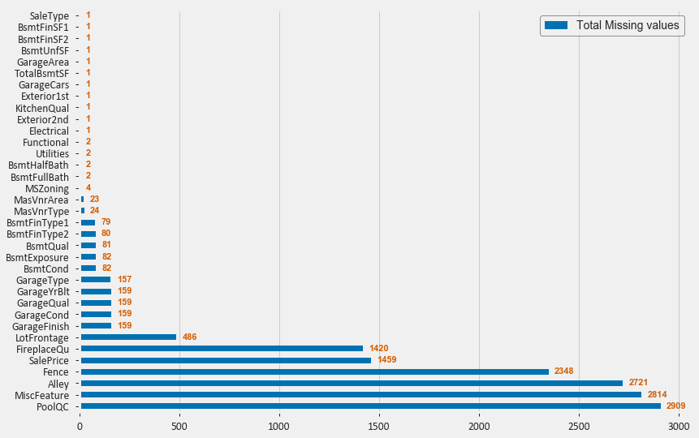

```python
#Import matplotlib packages

from matplotlib import rc, font_manager
import matplotlib.ticker as ticker

#Define parameters
style.use('fivethirtyeight')
sizeOfFont = 13.5
fontProperties = {'family':'sans-serif','sans-serif':['Helvetica'],
    'weight' : 'normal', 'size' : sizeOfFont}
ticks_font = font_manager.FontProperties(family='Calibri', style='normal',
    size=sizeOfFont, weight='normal', stretch='normal')

colors = [[0,0,0], [230/255,159/255,0], [86/255,180/255,233/255], [0,158/255,115/255],
          [213/255,94/255,0], [0,114/255,178/255]]

# Define a figure and size
f, ax = plt.subplots(figsize=(12,8.5))


#Identify missing value columns
a = df.columns[df.isnull().any()]
total = df.isnull().sum().sort_values(ascending=False)
percent = (df.isnull().sum()/df.isnull().count()).sort_values(ascending=False)
missing_data = pd.concat([total, percent], axis=1, keys=['Total', 'Percent'])
x = missing_data[missing_data['Total']>0]
x = x.drop('Percent',axis = 1)


#Plot the bar chart
x.plot(kind = 'barh',color = [[0,114/255,178/255]],ax=ax)


#Styling of ticks and ticklabels
for tick in ax.get_xticklabels():
    tick.set_fontproperties(ticks_font)

for tick in ax.get_yticklabels():
    tick.set_fontproperties(ticks_font)

ax.tick_params(length=5,axis = 'both', which = 'major')


# Add some data labels
y = x['Total'].tolist()

for i, v in enumerate(y):
    ax.text(v+30, i-0.2 , str(v), color=[213/255,94/255,0],fontsize= 11,fontweight='bold')


#Add Legend
L = ax.legend(frameon=True,prop={'size': 14})

L.get_texts()[0].set_text('Total Missing values')
L.get_frame().set_edgecolor('k')

ax.yaxis.grid(False)
```

**Since there are lots of missing values. I decided to define a function which would fill the null values**

```python
# Define a fucntion to fill the missing values
def fill_missing(data,column, value):
    data.loc[data[column].isnull(),column] = value
```

### PoolQC

PoolQC: Pool quality

```
   Ex   Excellent
   Gd   Good
   TA   Average/Typical
   Fa   Fair
   NA   No Pool
```

```
Training data:  Gd    3
Fa    2
Ex    2
Name: PoolQC, dtype: int64
Test data:  Ex    2
Gd    1
Name: PoolQC, dtype: int64
```

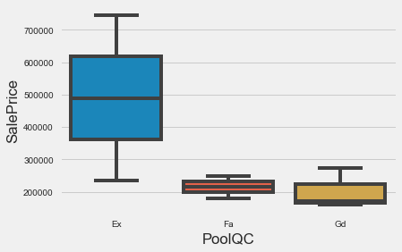

```python
print("Training data: " ,train_df['PoolQC'].value_counts())
print("Test data: " ,test_df['PoolQC'].value_counts())


sns.boxplot( x='PoolQC', y='SalePrice', data =df)

for tick in ax.get_xticklabels():
    tick.set_fontproperties(ticks_font)

for tick in ax.get_yticklabels():
    tick.set_fontproperties(ticks_font)
```

- Most of the data for PoolQC is missing.
- Assuming those houses dont have a swimming pool.I gave them a 'No_pool' value.

```python
print(train_df.loc[train_df['PoolQC'].isnull()]['PoolArea'].describe())
print(test_df.loc[test_df['PoolQC'].isnull()]['PoolArea'].describe())


#Fill the Missing value with "No_Pool"
fill_missing(train_df,'PoolQC','No_pool')
test_df.loc[(test_df['PoolArea'] != 0) & (test_df['PoolQC'].isnull()),'PoolQC'] = 'Gd'
fill_missing(test_df,'PoolQC','No_pool')
```

```
count    1453.0
mean        0.0
std         0.0
min         0.0
25%         0.0
50%         0.0
75%         0.0
max         0.0
Name: PoolArea, dtype: float64
count    1456.000000
mean        0.942995
std        21.070757
min         0.000000
25%         0.000000
50%         0.000000
75%         0.000000
max       561.000000
Name: PoolArea, dtype: float64
```

### MiscFeature

MiscFeature: Miscellaneous feature not covered in other categories

```
   Elev Elevator
   Gar2 2nd Garage (if not described in garage section)
   Othr Other
   Shed Shed (over 100 SF)
   TenC Tennis Court
   NA   None
```

- For Empty values - assuming none - probably no special features

```python
fill_missing(train_df,'MiscFeature','No_features')
fill_missing(test_df,'MiscFeature','No_features')
```

### Alley

Alley: Type of alley access to property

```
   Grvl Gravel
   Pave Paved
   NA   No alley access
```

- Missing value means No Alley

```python
fill_missing(train_df,'Alley','No_alley')
fill_missing(test_df,'Alley','No_alley')
```

### Fence

Fence: Fence quality

```
   GdPrv    Good Privacy
   MnPrv    Minimum Privacy
   GdWo Good Wood
   MnWw Minimum Wood/Wire
   NA   No Fence
```

- Missing value means No Fence

```python
fill_missing(train_df,'Fence','No_Fence')
fill_missing(test_df,'Fence','No_Fence')
```

### FireplaceQu

FireplaceQu: Fireplace quality

```
   Ex   Excellent - Exceptional Masonry Fireplace
   Gd   Good - Masonry Fireplace in main level
   TA   Average - Prefabricated Fireplace in main living area or Masonry Fireplace in basement
   Fa   Fair - Prefabricated Fireplace in basement
   Po   Poor - Ben Franklin Stove
   NA   No Fireplace
```

```python
train_df['FireplaceQu'].value_counts(),test_df['FireplaceQu'].value_counts()
```

```
(Gd    380
 TA    313
 Fa     33
 Ex     24
 Po     20
 Name: FireplaceQu, dtype: int64, Gd    364
 TA    279
 Fa     41
 Po     26
 Ex     19
 Name: FireplaceQu, dtype: int64)
```

**I checked Fireplace data to find if the missing Fireplace quality has a Fireplace or not**

```python
print(train_df['Fireplaces'][train_df['FireplaceQu'].isnull()==True].describe())
print(test_df['Fireplaces'][test_df['FireplaceQu'].isnull()==True].describe())
```

```
count    690.0
mean       0.0
std        0.0
min        0.0
25%        0.0
50%        0.0
75%        0.0
max        0.0
Name: Fireplaces, dtype: float64
count    730.0
mean       0.0
std        0.0
min        0.0
25%        0.0
50%        0.0
75%        0.0
max        0.0
Name: Fireplaces, dtype: float64
```

**As evident from 0 values, the missing values dont have a Fireplace**

```python
fill_missing(train_df,'FireplaceQu','No_fireplace')
fill_missing(test_df,'FireplaceQu','No_fireplace')
```

### LotFrontage

LotFrontage: Linear feet of street connected to property

- **A number of values are missing and one solution is to fill the data with mean.**
- **However, there should actually be a correlation with LotArea, which has no missing values.**

```python
# check correlation with LotArea
train_df['LotFrontage'].corr(train_df['LotArea']), test_df['LotFrontage'].corr(test_df['LotArea'])
```

```
(0.42609501877180816, 0.64460849777575191)
```

**Assuming most Lots are Rectangular, taking Square root of Lot Area would give us data in single dimension (For example- Linear Feet)**

```python
# Check correlation with Square root of LotArea
train_df['SqrtLotArea']=np.sqrt(train_df['LotArea'])
test_df['SqrtLotArea']=np.sqrt(test_df['LotArea'])
train_df['LotFrontage'].corr(train_df['SqrtLotArea']) , test_df['LotFrontage'].corr(test_df['SqrtLotArea'])
```

```
(0.6020022167939364, 0.7030019347771298)
```

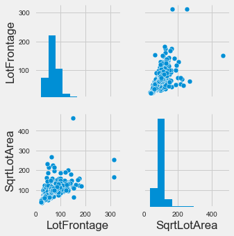

```python
sns.pairplot(train_df[['LotFrontage','SqrtLotArea']].dropna())
```

**Its obvious from the data and plot above that "LotFrontage" and "SqrtLotArea" have linear correlation.**  
**We will later predict "LotFrontage" using the "SqrtLotArea" and other correlated features**

### Garage features

```python
garage_cols=['GarageType','GarageQual','GarageCond','GarageYrBlt','GarageFinish','GarageCars','GarageArea']
train_df[garage_cols][train_df['GarageType'].isnull()==True].head(10)
```

|  | GarageType | GarageQual | GarageCond | GarageYrBlt | GarageFinish | GarageCars | GarageArea |
| --- | --- | --- | --- | --- | --- | --- | --- |
| 39 | NaN | NaN | NaN | NaN | NaN | 0 | 0 |
| 48 | NaN | NaN | NaN | NaN | NaN | 0 | 0 |
| 78 | NaN | NaN | NaN | NaN | NaN | 0 | 0 |
| 88 | NaN | NaN | NaN | NaN | NaN | 0 | 0 |
| 89 | NaN | NaN | NaN | NaN | NaN | 0 | 0 |
| 99 | NaN | NaN | NaN | NaN | NaN | 0 | 0 |
| 108 | NaN | NaN | NaN | NaN | NaN | 0 | 0 |
| 125 | NaN | NaN | NaN | NaN | NaN | 0 | 0 |
| 127 | NaN | NaN | NaN | NaN | NaN | 0 | 0 |
| 140 | NaN | NaN | NaN | NaN | NaN | 0 | 0 |

```python
test_df[garage_cols][test_df['GarageType'].isnull()==True].head(10)
```

|  | GarageType | GarageQual | GarageCond | GarageYrBlt | GarageFinish | GarageCars | GarageArea |
| --- | --- | --- | --- | --- | --- | --- | --- |
| 53 | NaN | NaN | NaN | NaN | NaN | 0.0 | 0.0 |
| 71 | NaN | NaN | NaN | NaN | NaN | 0.0 | 0.0 |
| 79 | NaN | NaN | NaN | NaN | NaN | 0.0 | 0.0 |
| 92 | NaN | NaN | NaN | NaN | NaN | 0.0 | 0.0 |
| 96 | NaN | NaN | NaN | NaN | NaN | 0.0 | 0.0 |
| 98 | NaN | NaN | NaN | NaN | NaN | 0.0 | 0.0 |
| 100 | NaN | NaN | NaN | NaN | NaN | 0.0 | 0.0 |
| 130 | NaN | NaN | NaN | NaN | NaN | 0.0 | 0.0 |
| 133 | NaN | NaN | NaN | NaN | NaN | 0.0 | 0.0 |
| 134 | NaN | NaN | NaN | NaN | NaN | 0.0 | 0.0 |

```python
#Garage Imputation
for cols in garage_cols:
    if test_df[cols].dtype==np.object:
        fill_missing(test_df,cols,'None')
    else:
        fill_missing(test_df,cols, 0)

for cols in garage_cols:
    if train_df[cols].dtype==np.object:
        fill_missing(train_df,cols,'None')
    else:
        fill_missing(train_df,cols, 0)
```

### Basement Features

```python
basement_cols=['BsmtQual','BsmtCond','BsmtExposure','BsmtFinType1','BsmtFinType2','BsmtFinSF1','BsmtFinSF2']
train_df[basement_cols][train_df['BsmtQual'].isnull()==True].head(10)
```

|  | BsmtQual | BsmtCond | BsmtExposure | BsmtFinType1 | BsmtFinType2 | BsmtFinSF1 | BsmtFinSF2 |
| --- | --- | --- | --- | --- | --- | --- | --- |
| 17 | NaN | NaN | NaN | NaN | NaN | 0 | 0 |
| 39 | NaN | NaN | NaN | NaN | NaN | 0 | 0 |
| 90 | NaN | NaN | NaN | NaN | NaN | 0 | 0 |
| 102 | NaN | NaN | NaN | NaN | NaN | 0 | 0 |
| 156 | NaN | NaN | NaN | NaN | NaN | 0 | 0 |
| 182 | NaN | NaN | NaN | NaN | NaN | 0 | 0 |
| 259 | NaN | NaN | NaN | NaN | NaN | 0 | 0 |
| 342 | NaN | NaN | NaN | NaN | NaN | 0 | 0 |
| 362 | NaN | NaN | NaN | NaN | NaN | 0 | 0 |
| 371 | NaN | NaN | NaN | NaN | NaN | 0 | 0 |

```python
test_df[basement_cols][test_df['BsmtQual'].isnull()==True].head(10)
```

|  | BsmtQual | BsmtCond | BsmtExposure | BsmtFinType1 | BsmtFinType2 | BsmtFinSF1 | BsmtFinSF2 |
| --- | --- | --- | --- | --- | --- | --- | --- |
| 125 | NaN | NaN | NaN | NaN | NaN | 0.0 | 0.0 |
| 133 | NaN | NaN | NaN | NaN | NaN | 0.0 | 0.0 |
| 269 | NaN | NaN | NaN | NaN | NaN | 0.0 | 0.0 |
| 318 | NaN | NaN | NaN | NaN | NaN | 0.0 | 0.0 |
| 354 | NaN | NaN | NaN | NaN | NaN | 0.0 | 0.0 |
| 387 | NaN | NaN | NaN | NaN | NaN | 0.0 | 0.0 |
| 388 | NaN | NaN | NaN | NaN | NaN | 0.0 | 0.0 |
| 396 | NaN | NaN | NaN | NaN | NaN | 0.0 | 0.0 |
| 397 | NaN | NaN | NaN | NaN | NaN | 0.0 | 0.0 |
| 398 | NaN | NaN | NaN | NaN | NaN | 0.0 | 0.0 |

**Again in the cases where the categorical variables are NaN, the numerical ones are 0.**  
**Which means there's no basement, so the categorical missing variables should also be set to "None"**

```python
for cols in basement_cols:
    if 'FinSF'not in cols:
        fill_missing(train_df,cols,'None')

for cols in basement_cols:
    if 'FinSF'not in cols:
        fill_missing(test_df,cols,'None')
```

### MasVnr

MasVnr: Masonry veneer type

```
   BrkCmn   Brick Common
   BrkFace  Brick Face
   CBlock   Cinder Block
   None None
   Stone    Stone
```

```python
df[['MasVnrType','MasVnrArea']][df['MasVnrType'].isnull()==True]
```

|  | MasVnrType | MasVnrArea |
| --- | --- | --- |
| 234 | NaN | NaN |
| 529 | NaN | NaN |
| 650 | NaN | NaN |
| 936 | NaN | NaN |
| 973 | NaN | NaN |
| 977 | NaN | NaN |
| 1243 | NaN | NaN |
| 1278 | NaN | NaN |
| 1691 | NaN | NaN |
| 1706 | NaN | NaN |
| 1882 | NaN | NaN |
| 1992 | NaN | NaN |
| 2004 | NaN | NaN |
| 2041 | NaN | NaN |
| 2311 | NaN | NaN |
| 2325 | NaN | NaN |
| 2340 | NaN | NaN |
| 2349 | NaN | NaN |
| 2368 | NaN | NaN |
| 2592 | NaN | NaN |
| 2610 | NaN | 198.0 |
| 2657 | NaN | NaN |
| 2686 | NaN | NaN |
| 2862 | NaN | NaN |

```
None       1742
BrkFace     879
Stone       249
BrkCmn       25
Name: MasVnrType, dtype: int64
```

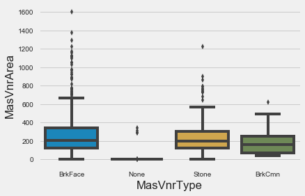

```python
sns.boxplot(x = 'MasVnrType', y='MasVnrArea',data= df)
df['MasVnrType'].value_counts()
```

**Except for the values at index 1150, both columns have none values.**  
**Since 'BrkFace' is most common value after None,lets fill that value for index 1150 and 'None' for rest.**

```python
test_df.loc[1150,'MasVnrType'] = 'BrkFace'

fill_missing(train_df,'MasVnrType', 'None')
fill_missing(test_df,'MasVnrType', 'None')
fill_missing(train_df,'MasVnrArea', 0.0)
fill_missing(test_df,'MasVnrArea', 0.0)
```

### Electrical

Electrical: Electrical system

```
   SBrkr    Standard Circuit Breakers & Romex
   FuseA    Fuse Box over 60 AMP and all Romex wiring (Average)
   FuseF    60 AMP Fuse Box and mostly Romex wiring (Fair)
   FuseP    60 AMP Fuse Box and mostly knob & tube wiring (poor)
   Mix  Mixed
```

```python
train_df['Electrical'].value_counts(),test_df['Electrical'].value_counts()
```

```
(SBrkr    1334
 FuseA      94
 FuseF      27
 FuseP       3
 Mix         1
 Name: Electrical, dtype: int64, SBrkr    1337
 FuseA      94
 FuseF      23
 FuseP       5
 Name: Electrical, dtype: int64)
```

Both dataset has SBrkr as the most frequent value  
Lets fill missing values with this value.

```python
fill_missing(train_df,'Electrical','SBrkr')
fill_missing(test_df,'Electrical','SBrkr')
```

```python
df = train_df.append(test_df)
#df.info()
df.head()
```

|  | 1stFlrSF | 2ndFlrSF | 3SsnPorch | Alley | BedroomAbvGr | BldgType | BsmtCond | BsmtExposure | BsmtFinSF1 | BsmtFinSF2 | ... | ScreenPorch | SqrtLotArea | Street | TotRmsAbvGrd | TotalBsmtSF | Utilities | WoodDeckSF | YearBuilt | YearRemodAdd | YrSold |
| --- | --- | --- | --- | --- | --- | --- | --- | --- | --- | --- | --- | --- | --- | --- | --- | --- | --- | --- | --- | --- | --- |
| 0 | 856 | 854 | 0 | No_alley | 3 | 1Fam | TA | No | 706.0 | 0.0 | ... | 0 | 91.923882 | Pave | 8 | 856.0 | AllPub | 0 | 2003 | 2003 | 2008 |
| 1 | 1262 | 0 | 0 | No_alley | 3 | 1Fam | TA | Gd | 978.0 | 0.0 | ... | 0 | 97.979590 | Pave | 6 | 1262.0 | AllPub | 298 | 1976 | 1976 | 2007 |
| 2 | 920 | 866 | 0 | No_alley | 3 | 1Fam | TA | Mn | 486.0 | 0.0 | ... | 0 | 106.066017 | Pave | 6 | 920.0 | AllPub | 0 | 2001 | 2002 | 2008 |
| 3 | 961 | 756 | 0 | No_alley | 3 | 1Fam | Gd | No | 216.0 | 0.0 | ... | 0 | 97.724101 | Pave | 7 | 756.0 | AllPub | 0 | 1915 | 1970 | 2006 |
| 4 | 1145 | 1053 | 0 | No_alley | 4 | 1Fam | TA | Av | 655.0 | 0.0 | ... | 0 | 119.415242 | Pave | 9 | 1145.0 | AllPub | 192 | 2000 | 2000 | 2008 |

5 rows × 82 columns

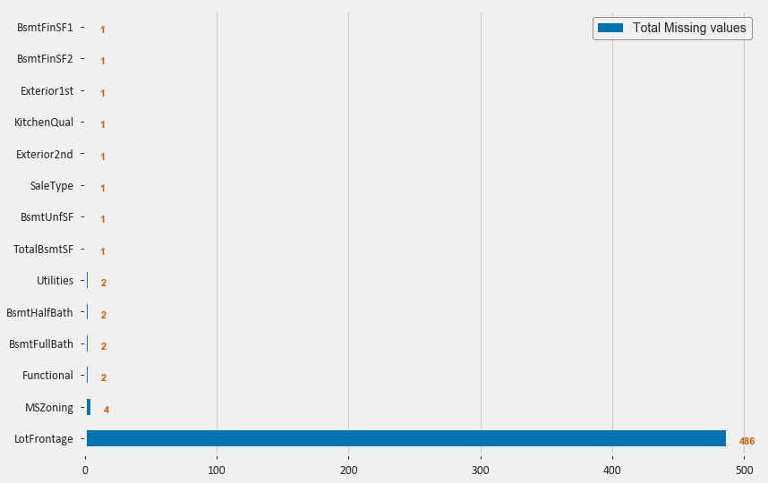

```python
#Define parameters
style.use('fivethirtyeight')
sizeOfFont = 13.5
fontProperties = {'family':'sans-serif','sans-serif':['Helvetica'],
    'weight' : 'normal', 'size' : sizeOfFont}
ticks_font = font_manager.FontProperties(family='Calibri', style='normal',
    size=sizeOfFont, weight='normal', stretch='normal')

colors = [[0,0,0], [230/255,159/255,0], [86/255,180/255,233/255], [0,158/255,115/255],
          [213/255,94/255,0], [0,114/255,178/255]]

# Define a figure and size
f, ax = plt.subplots(figsize=(12,8.5))


#Identify missing value columns
a = df.columns[df.isnull().any()]
total = df.isnull().sum().sort_values(ascending=False)
percent = (df.isnull().sum()/df.isnull().count()).sort_values(ascending=False)
missing_data = pd.concat([total, percent], axis=1, keys=['Total', 'Percent'])
x = missing_data[missing_data['Total']>0]
x = x.drop('Percent',axis = 1)


#Plot the bar chart
x[1:].plot(kind = 'barh',color = [[0,114/255,178/255]],ax=ax)


#Styling of ticks and ticklabels
for tick in ax.get_xticklabels():
    tick.set_fontproperties(ticks_font)

for tick in ax.get_yticklabels():
    tick.set_fontproperties(ticks_font)

ax.tick_params(length=5,axis = 'both', which = 'major')


# Add some data labels
y = x[1:]['Total'].tolist()

for i, v in enumerate(y):
    ax.text(v+10, i-0.2 , str(v), color=[213/255,94/255,0],fontsize= 11,fontweight='bold')


#Add Legend
L = ax.legend(frameon=True,prop={'size': 14})

L.get_texts()[0].set_text('Total Missing values')
L.get_frame().set_edgecolor('k')

ax.yaxis.grid(False)
```

**I filled the rest of missing categorical values with most frequent values**

```python
l = ['MSZoning',
     'Utilities',
 'BsmtHalfBath',
 'BsmtFullBath',
 'Functional',
 'BsmtFinSF2',
 'Exterior1st',
 'Exterior2nd',
 'BsmtUnfSF',
 'KitchenQual',
 'BsmtFinSF1',
 'SaleType',
 'TotalBsmtSF']
#Fill Null values with most frequent values
for a in l:
    value = df[a].value_counts().idxmax()
    fill_missing(df,a,value)
    fill_missing(test_df,a,value)
df.columns[df.isnull().any()]
```

```
Index(['LotFrontage', 'SalePrice'], dtype='object')
```

```python
df.to_csv('Cleaned_House_data.csv',index=False)
train_df.to_csv('train_cleaned.csv',index=False)
test_df.to_csv('test_cleaned.csv',index=False)
```